# Case study

Classification of advertisement mails

Jalal Alizadeh

24.03.2021

# 1 Statistical methods

## 1.1 Glossary

Below are the definitions and equations of the commonly used terms in classification problems.

- Confusion matrix: contingency table representing how accurately are the events classified

|  |  | Condition positive True | Condition positive False |
| --- | --- | --- | --- |
| Predicted condition | True | True positive | False positive |
|  | False | False negative | True negative |

- Accuracy: proportion of correctly classified events.

$Accuracy = \frac{\sum True\: positive + \sum True\: negative}{\sum Total\: population}$

- Recall, Sensitivity or True positive rate: fraction of positive events that are successfully classified as such.

$Recall = \frac{\sum True\: positive}{\sum Condition\: positive} = \frac{\sum True\: positive}{\sum Tru\:e positive + \sum False\: negative}$

- Specificity, True negative rate: fraction of the negative events that are correctly classified as such.

$Specificity = \frac{\sum True\: negative}{\sum Condition\: negative} = \frac{\sum True\: negative}{\sum True\: negative + \sum False\: positive}$

- Precision, Positive predictive value: proportion of the positive events that are predicted as such.

$Precision = \frac{\sum True\: positive}{\sum Predicted\: positive} = \frac{\sum True\: positive}{\sum True\: positive + \sum False\:\: positive}$

- Negative predictive value: proportion of the positive events that are predicted as such.

$Negative\: predictive\: value = \frac{\sum True\: negative}{\sum Predicted\: negative} = \frac{\sum True\: negative}{\sum True\: negative + \sum False\: negative}$

- F1 score: combined measure of precision and recall.

$F1 = 2.\frac{Precision.Recall}{Precision+Recall}$

## 1.2 Statistical methods

### 1.2.1 Model training and selection

Response to advertisement mails was predicted using various machine learning algorithms, trained on data with nine features. The initial data is splitted and 25% is set aside as a test set and five concurrent models were evaluated. Each model contained the following variables: age, earnings, family status, type of car, living area, life style, type of sports, broader and a bit narrower areas extracted from zip codes.

The zip code is converted to two columns namely broad area and county using first digit and first three digits of zip code, respectively. The new columns are considered as high cardinality variable which contain relatively a high number of unique values. One way to handle this kind of variable is to use weight of evidence (WoE) approach in which predictive power of an independent variable in relation to the dependent variable is calculated and replaced.

Other categorical variables with two, three and four levels are encoded as dummy encoding in which n-1 (n: number of levels) new columns are generated and assigned to numerical values. Another procedure also was investigated on categorical variables with more than 2 levels, where WoE approach was applied to reduce sparsity to some extend. According to the results, dummy encoding showed better performance, therefore, test and training sets are generated based on WoE approach (only on zip codes columns) and dummy encoding (other categorical variables).

All the variables are scaled and centered before the analyses. This was done on training set, stored the mean and standard deviation of training variables and then scaled and centered test set based on the stored values.

# 2 Results

## 2.1 Descriptive statistics

### 2.1.1 Training descriptive analysis

| Variable | Overall, N = 7,5001 | Response 0, N = 5,0141 | Response 1, N = 2,4861 | p-value2 |
| --- | --- | --- | --- | --- |
| age | 42 (28, 56) | 36 (26, 47) | 59 (43, 64) | <0.001 |
| lifestyle |  |  |  | 0.96 |
| active | 2,507 (33%) | 1,671 (33%) | 836 (34%) |  |
| cozily | 2,524 (34%) | 1,692 (34%) | 832 (33%) |  |
| healthy | 2,469 (33%) | 1,651 (33%) | 818 (33%) |  |
| family.status |  |  |  | 0.37 |
| married | 3,790 (51%) | 2,552 (51%) | 1,238 (50%) |  |
| single | 3,710 (49%) | 2,462 (49%) | 1,248 (50%) |  |
| car |  |  |  | 0.71 |
| expensive | 3,700 (49%) | 2,466 (49%) | 1,234 (50%) |  |
| practical | 3,800 (51%) | 2,548 (51%) | 1,252 (50%) |  |
| sports |  |  |  | 0.047 |
| other | 1,114 (15%) | 708 (14%) | 406 (16%) |  |
| athletics | 2,116 (28%) | 1,427 (28%) | 689 (28%) |  |
| badminton | 2,133 (28%) | 1,419 (28%) | 714 (29%) |  |
| soccer | 2,137 (28%) | 1,460 (29%) | 677 (27%) |  |
| earnings | 84,892 (53,024, 117,561) | 80,286 (50,812, 111,298) | 96,554 (57,646, 133,668) | <0.001 |
| living.area |  |  |  | 0.78 |
| rural | 2,804 (37%) | 1,880 (37%) | 924 (37%) |  |
| urban | 4,696 (63%) | 3,134 (63%) | 1,562 (63%) |  |
| broadArea |  |  |  | <0.001 |
| 1 | 873 (12%) | 378 (7.5%) | 495 (20%) |  |
| 2 | 791 (11%) | 538 (11%) | 253 (10%) |  |
| 3 | 831 (11%) | 592 (12%) | 239 (9.6%) |  |
| 4 | 806 (11%) | 571 (11%) | 235 (9.5%) |  |
| 5 | 840 (11%) | 589 (12%) | 251 (10%) |  |
| 6 | 823 (11%) | 581 (12%) | 242 (9.7%) |  |
| 7 | 819 (11%) | 577 (12%) | 242 (9.7%) |  |
| 8 | 842 (11%) | 571 (11%) | 271 (11%) |  |
| 9 | 875 (12%) | 617 (12%) | 258 (10%) |  |
| county | 551 (324, 782) | 571 (356, 790) | 508 (246, 758) | <0.001 |

1Median (IQR) or Frequency (%)  
2Wilcoxon rank sum test; Pearson's Chi-squared test

### 2.1.2 Test descriptive analysis

| Variable | Overall, N = 2,5001 | Response 0, N = 1,6261 | Response 1, N = 8741 | p-value2 |
| --- | --- | --- | --- | --- |
| age | 42 (28, 57) | 36 (26, 47) | 59 (45, 65) | <0.001 |
| lifestyle |  |  |  | 0.17 |
| active | 868 (35%) | 586 (36%) | 282 (32%) |  |
| cozily | 822 (33%) | 525 (32%) | 297 (34%) |  |
| healthy | 810 (32%) | 515 (32%) | 295 (34%) |  |
| family.status |  |  |  | 0.034 |
| married | 1,242 (50%) | 833 (51%) | 409 (47%) |  |
| single | 1,258 (50%) | 793 (49%) | 465 (53%) |  |
| car |  |  |  | 0.89 |
| expensive | 1,249 (50%) | 814 (50%) | 435 (50%) |  |
| practical | 1,251 (50%) | 812 (50%) | 439 (50%) |  |
| sports |  |  |  | 0.19 |
| other | 386 (15%) | 238 (15%) | 148 (17%) |  |
| athletics | 737 (29%) | 479 (29%) | 258 (30%) |  |
| badminton | 695 (28%) | 472 (29%) | 223 (26%) |  |
| soccer | 682 (27%) | 437 (27%) | 245 (28%) |  |
| earnings | 88,656 (54,096, 119,485) | 84,232 (51,762, 113,518) | 96,217 (58,146, 135,368) | <0.001 |
| living.area |  |  |  | 0.30 |
| rural | 896 (36%) | 571 (35%) | 325 (37%) |  |
| urban | 1,604 (64%) | 1,055 (65%) | 549 (63%) |  |
| broadArea |  |  |  | <0.001 |
| 1 | 273 (11%) | 109 (6.7%) | 164 (19%) |  |
| 2 | 260 (10%) | 170 (10%) | 90 (10%) |  |
| 3 | 271 (11%) | 178 (11%) | 93 (11%) |  |
| 4 | 287 (11%) | 197 (12%) | 90 (10%) |  |
| 5 | 278 (11%) | 199 (12%) | 79 (9.0%) |  |
| 6 | 291 (12%) | 198 (12%) | 93 (11%) |  |
| 7 | 298 (12%) | 208 (13%) | 90 (10%) |  |
| 8 | 247 (9.9%) | 169 (10%) | 78 (8.9%) |  |
| 9 | 295 (12%) | 198 (12%) | 97 (11%) |  |
| county | 556 (333, 771) | 577 (369, 781) | 500 (256, 749) | <0.001 |

1Median (IQR) or Frequency (%)  
2Wilcoxon rank sum test; Pearson's Chi-squared test

## 2.2 Model training

The metrics presented below are computed during the cross-validation process

### 2.2.1 Cross-validation metrics

#### 2.2.1.1 GLM

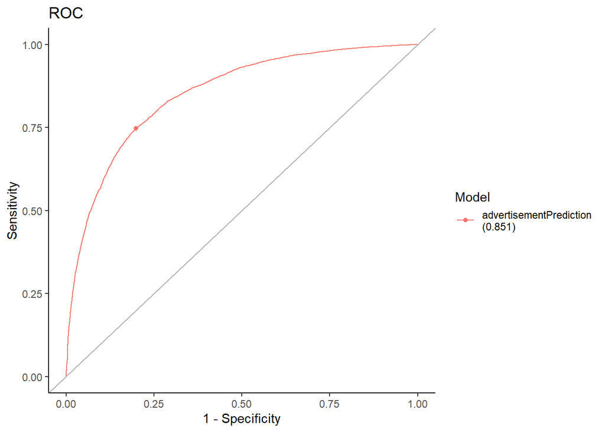

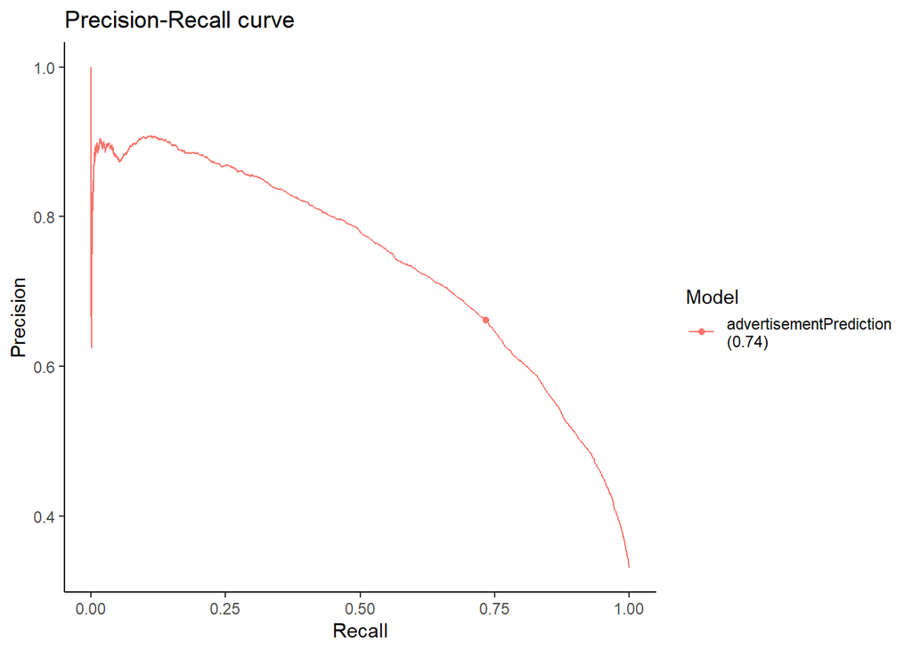

#### 2.2.1.2 RF

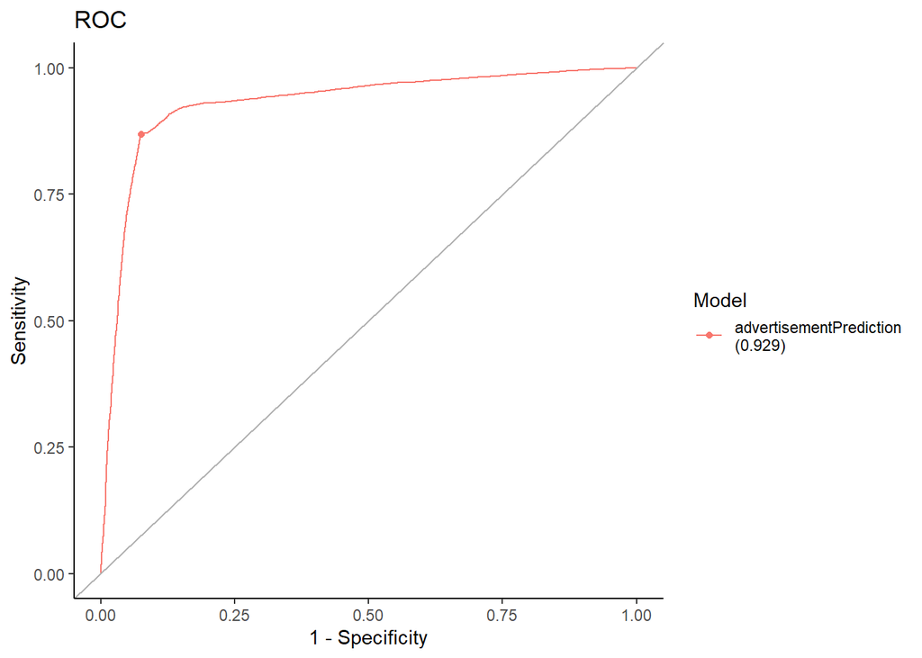

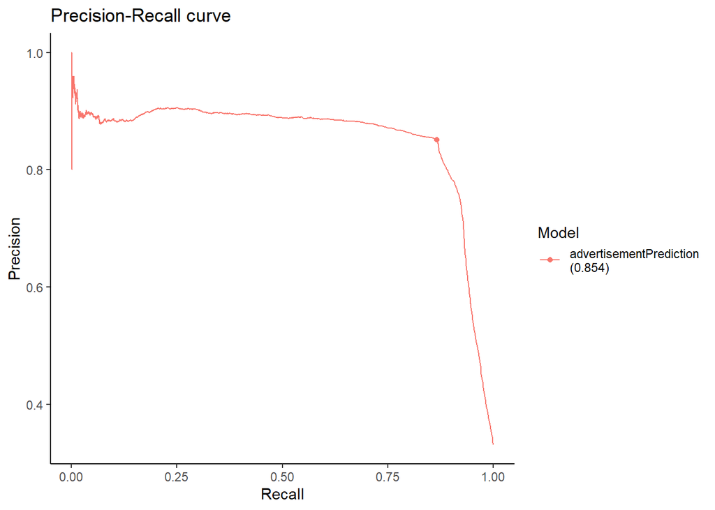

#### 2.2.1.3 GBM

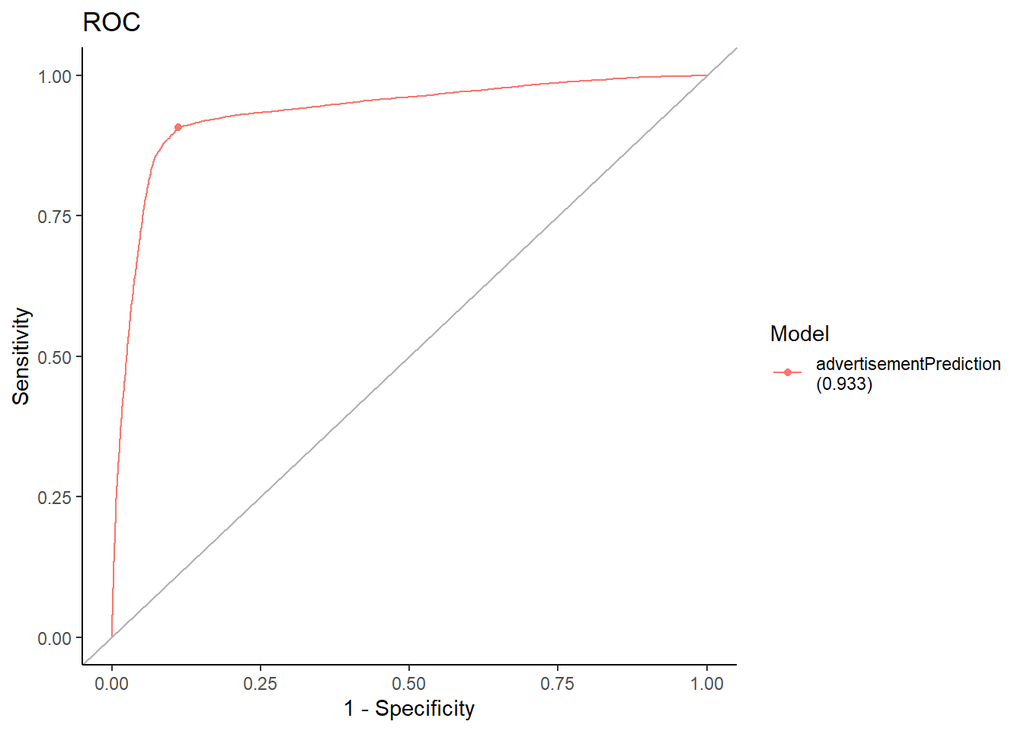

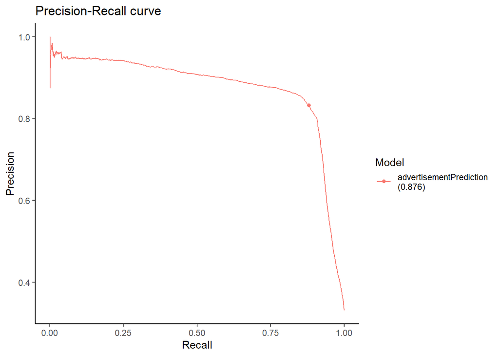

#### 2.2.1.4 SVM

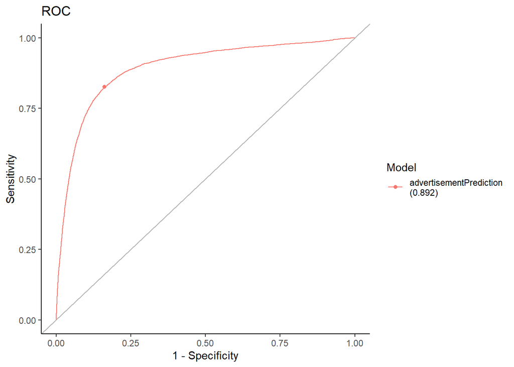

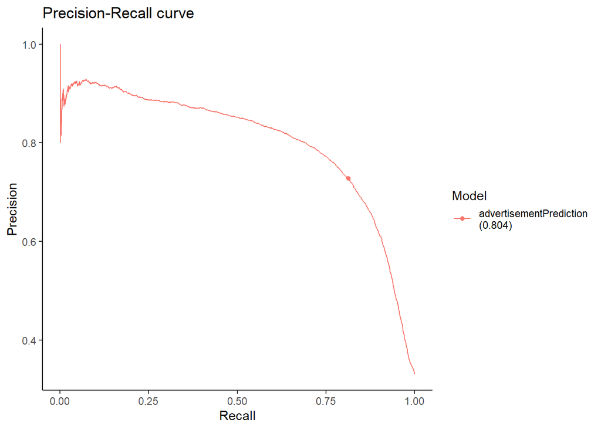

#### 2.2.1.5 DT

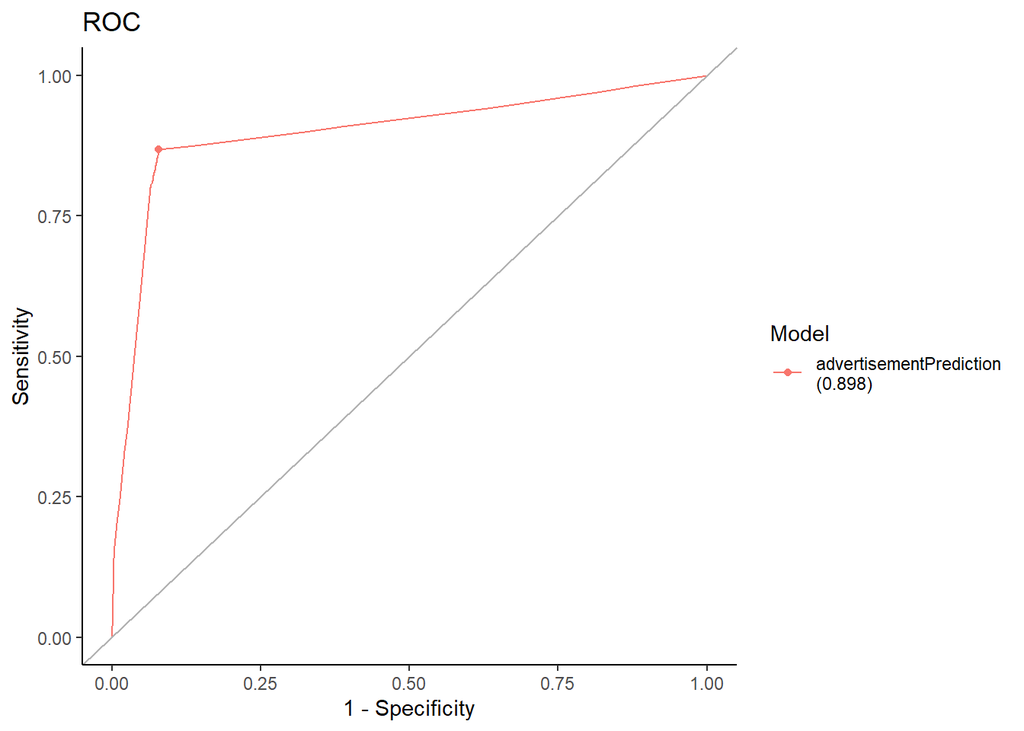

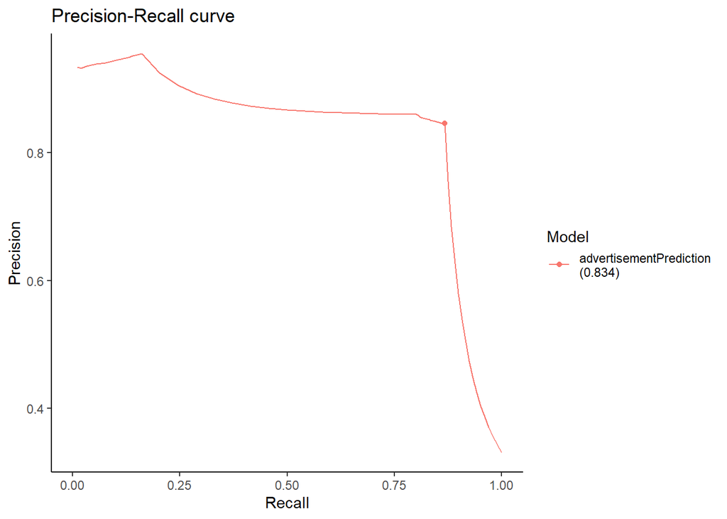

### 2.2.2 Variable importance

#### 2.2.2.1 GLM

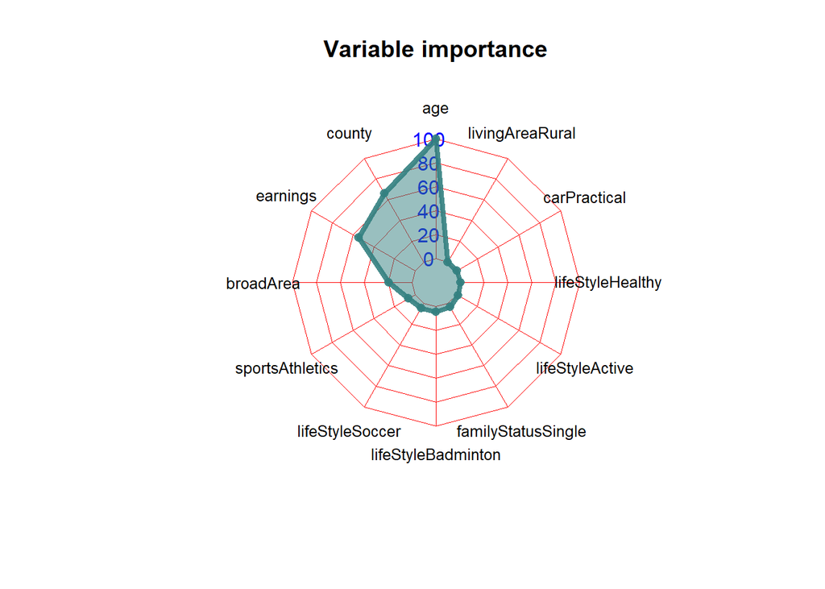

#### 2.2.2.2 RF

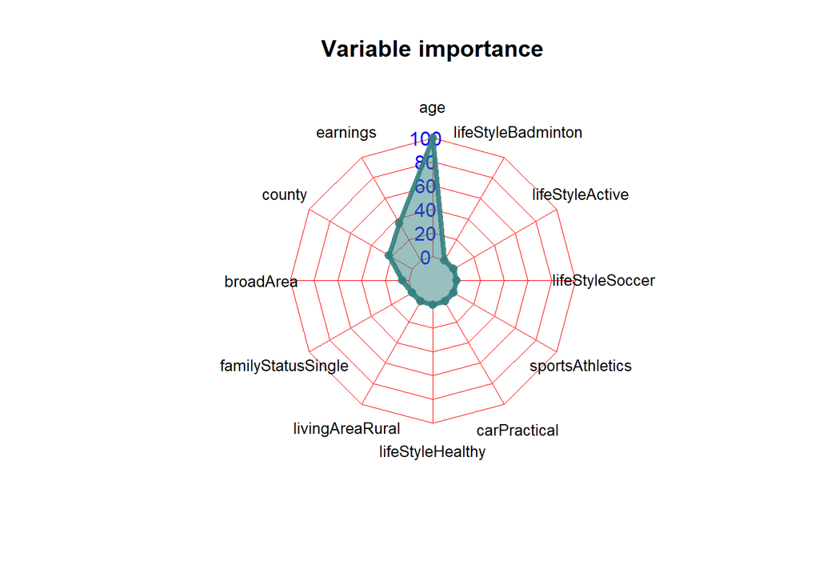

#### 2.2.2.3 GBM

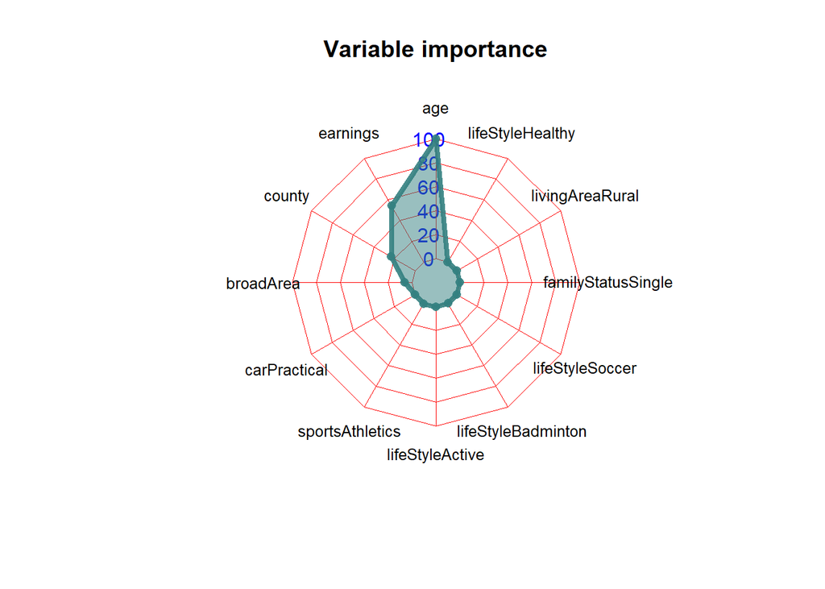

#### 2.2.2.4 SVM

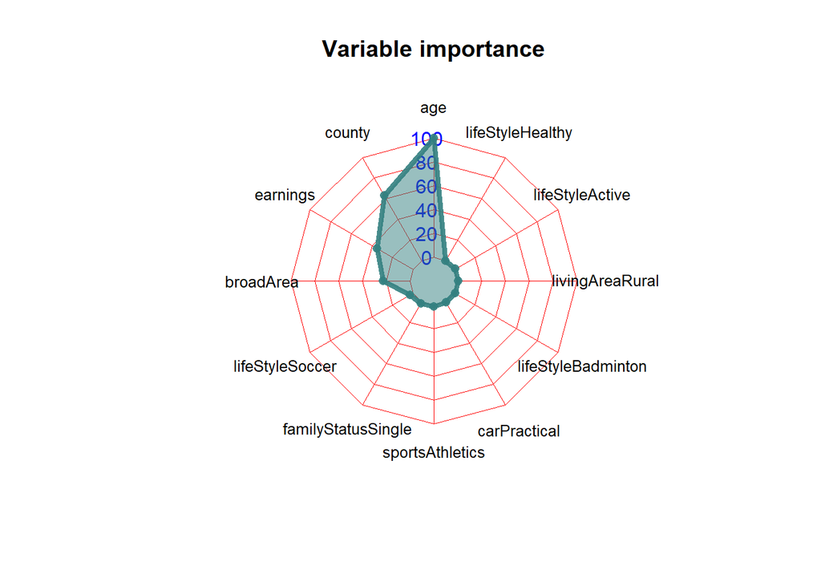

#### 2.2.2.5 DT

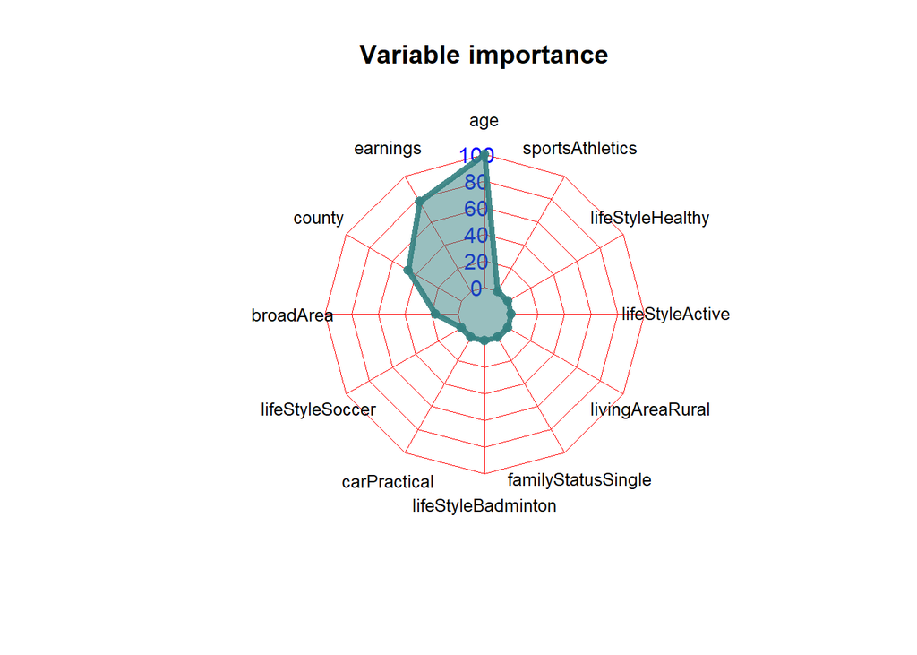

## 2.3 Model test

The metrics and results presented below are computed using the test set (25% of the original set) and the model specification performing the best during cross-validation.

### 2.3.1 Receiver operator curve

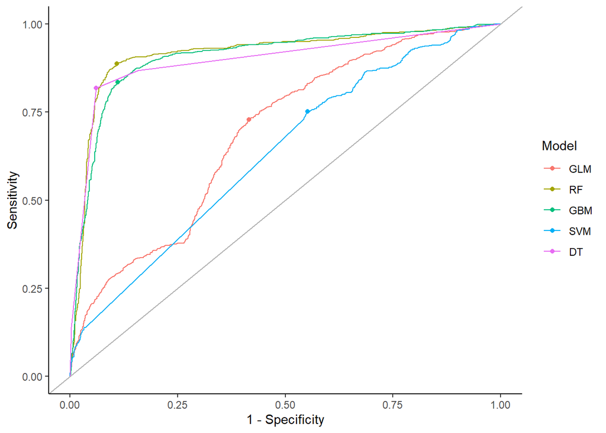

### 2.3.2 Precision-Recall curve

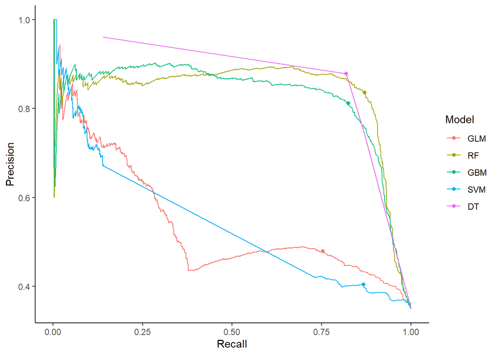

### 2.3.3 Discrimination metrics

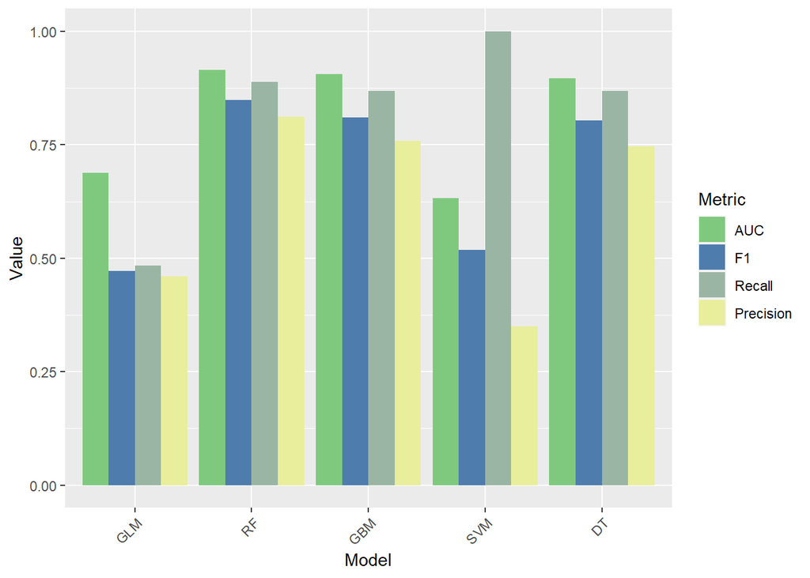

## 2.4 Final model architecture

As of results, random forest, gradient boosting method and decision tree performed best to distinguish response from non-response. To have a clear overview of final model, a decision with is trained on all input data (the same data engineering is done) and rules of classification are extracted.

### 2.4.1 Prediction rules

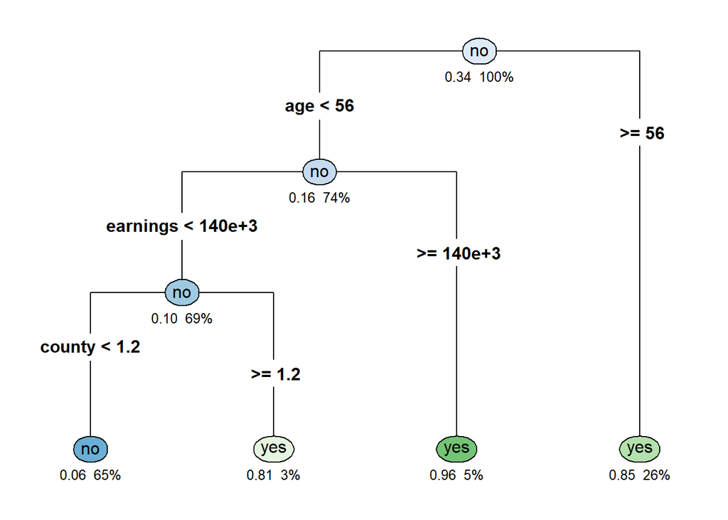

### 2.4.2 Map county information

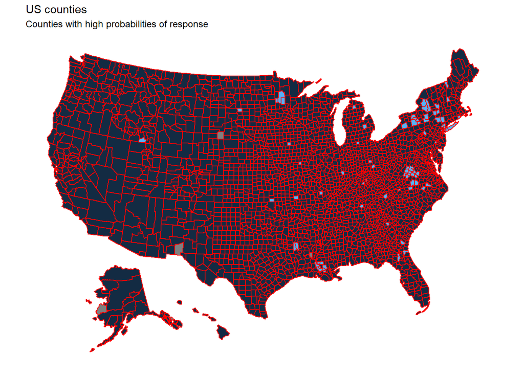

# References

Boyd, Kendrick, Kevin H. Eng, and C. David Page. 2013. “Area Under the Precision-Recall Curve: Point Estimates and Confidence Intervals.” *Machine Learning and Knowledge Discovery in Databases* 8190: 451–66. https://doi.org/10.1007/978-3-642-40994-3_29.